# Control Estadístico de Procesos – Línea de Ensamble de Cubos Lego

Secciones 6 y 7: Estudio de Capacidad y Estabilidad Estadística

Raúl Antonio Ruano Katz — versión de portafolio de un proyecto académico grupal

05 de October de 2026

# 1 Estudio de Capacidad Integral

El estudio de capacidad tiene como propósito determinar si el proceso de ensamble de cubos Lego es capaz de cumplir consistentemente con las especificaciones establecidas. La variable de interés es el tiempo de ciclo de ensamble (en segundos), con un valor nominal de **35 s**, un Límite de Especificación Inferior (LIE) de **30 s** y un Límite de Especificación Superior (LSE) de **40 s**.

## 1.1 Análisis de Estadística Descriptiva

En esta sección se presenta un resumen estadístico de las 40 observaciones individuales recopiladas durante las 10 muestras del estudio.

### 1.1.1 Tabla de Datos Recopilados

La siguiente tabla muestra las observaciones crudas organizadas por subgrupo, junto con la media ($\bar{X}$) y el rango ($R$) calculados para cada uno.

```r
# ============================================================
# Construcción de la tabla de datos con medias y rangos
# ============================================================
tabla_resumen <- tiempos_lego %>%
  rowwise() %>%
  mutate(
    Media_Xbar = round(mean(c(Obs1, Obs2, Obs3, Obs4)), 4),
    Rango_R    = round(max(c(Obs1, Obs2, Obs3, Obs4)) -
                       min(c(Obs1, Obs2, Obs3, Obs4)), 4)
  ) %>%
  ungroup()

# Presentación de la tabla con formato
tabla_resumen %>%
  kable(
    caption   = "Tabla 1. Observaciones de tiempo de ciclo por subgrupo (segundos)",
    col.names = c("Muestra", "Obs. 1", "Obs. 2", "Obs. 3", "Obs. 4",
                  "$\\bar{X}$", "$R$"),
    align     = "c",
    digits    = 4
  ) %>%
  kable_styling(
    bootstrap_options = c("striped", "hover", "bordered", "condensed"),
    full_width        = FALSE,
    position          = "center"
  ) %>%
  column_spec(6:7, bold = TRUE, color = "#2C3E50") %>%
  row_spec(0, bold = TRUE, background = "#2980B9", color = "white")
```

Tabla 1. Observaciones de tiempo de ciclo por subgrupo (segundos)

| Muestra | Obs. 1 | Obs. 2 | Obs. 3 | Obs. 4 | $\bar{X}$ | $R$ |
| --- | --- | --- | --- | --- | --- | --- |
| 1 | 35.5 | 34.9 | 35.6 | 36.5 | 35.625 | 1.6 |
| 2 | 34.8 | 34.8 | 36.6 | 35.8 | 35.500 | 1.8 |
| 3 | 34.5 | 35.5 | 34.5 | 34.5 | 34.750 | 1.0 |
| 4 | 35.2 | 33.1 | 33.3 | 34.4 | 34.000 | 2.1 |
| 5 | 34.0 | 35.3 | 34.1 | 33.6 | 34.250 | 1.7 |
| 6 | 36.5 | 34.8 | 35.1 | 33.6 | 35.000 | 2.9 |
| 7 | 34.5 | 35.1 | 33.8 | 35.4 | 34.700 | 1.6 |
| 8 | 34.4 | 34.7 | 34.4 | 36.9 | 35.100 | 2.5 |
| 9 | 35.0 | 33.9 | 35.8 | 33.8 | 34.625 | 2.0 |
| 10 | 35.2 | 33.0 | 33.7 | 35.2 | 34.275 | 2.2 |

### 1.1.2 Estadísticas Descriptivas Globales

```r
# ============================================================
# Cálculo de estadísticas descriptivas de los datos individuales
# ============================================================

# Media global (gran media)
media_global <- mean(todos_datos)

# Desviación estándar muestral (estimada a partir de datos individuales)
sd_global <- sd(todos_datos)

# Varianza muestral
var_global <- var(todos_datos)

# Mediana
mediana_global <- median(todos_datos)

# Valor mínimo y máximo
min_global <- min(todos_datos)
max_global <- max(todos_datos)

# Coeficiente de variación (%)
cv_global <- (sd_global / media_global) * 100

# Tabla de estadísticas descriptivas
estadisticas_df <- data.frame(
  Estadístico = c(
    "Número total de observaciones (N)",
    "Media global ($\\bar{\\bar{X}}$)",
    "Desviación estándar muestral ($s$)",
    "Varianza muestral ($s^2$)",
    "Mediana",
    "Valor mínimo",
    "Valor máximo",
    "Coeficiente de variación (CV%)"
  ),
  Valor = c(
    length(todos_datos),
    round(media_global, 4),
    round(sd_global,    4),
    round(var_global,   4),
    round(mediana_global, 4),
    round(min_global,   4),
    round(max_global,   4),
    round(cv_global,    4)
  )
)

estadisticas_df %>%
  kable(
    caption = "Tabla 2. Estadísticas descriptivas de los tiempos de ciclo individuales",
    align   = c("l", "c"),
    escape  = FALSE
  ) %>%
  kable_styling(
    bootstrap_options = c("striped", "hover", "bordered"),
    full_width        = FALSE,
    position          = "center"
  ) %>%
  row_spec(0, bold = TRUE, background = "#2980B9", color = "white")
```

Tabla 2. Estadísticas descriptivas de los tiempos de ciclo individuales

| Estadístico | Valor |
| --- | --- |
| Número total de observaciones (N) | 40.0000 |
| Media global ($\bar{\bar{X}}$) | 34.7825 |
| Desviación estándar muestral ($s$) | 0.9557 |
| Varianza muestral ($s^2$) | 0.9133 |
| Mediana | 34.8000 |
| Valor mínimo | 33.0000 |
| Valor máximo | 36.9000 |
| Coeficiente de variación (CV%) | 2.7475 |

Se observa que la media global del proceso ($\bar{\bar{X}}$ = **34.7825 s**) se encuentra próxima al valor nominal de 35 s. La desviación estándar estimada ($s$ = **0.9557 s**) y la varianza ($s^2$ = **0.9133 s²**) cuantifican la dispersión inherente del proceso. El coeficiente de variación del **2.75%** sugiere una dispersión relativamente baja en relación con la media.

### 1.1.3 Histograma de Distribución respecto a las Especificaciones

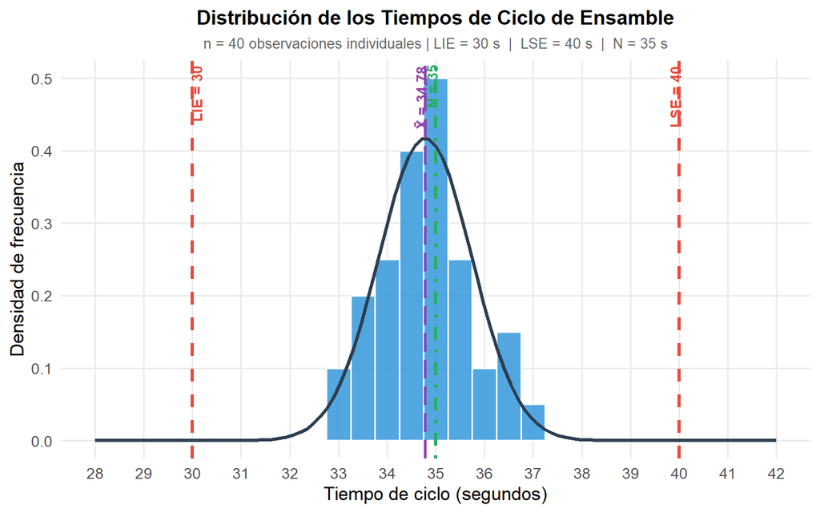

Figura 1. Histograma de los tiempos de ciclo individuales con límites de especificación

```r
# ============================================================
# Histograma de datos individuales con LIE, LSE y Nominal
# ============================================================
df_hist <- data.frame(tiempo = todos_datos)

ggplot(df_hist, aes(x = tiempo)) +
  # Histograma con densidad de frecuencia
  geom_histogram(
    aes(y = after_stat(density)),
    binwidth = 0.5,
    fill     = "#3498DB",
    color    = "white",
    alpha    = 0.85
  ) +
  # Curva de densidad normal superpuesta
  stat_function(
    fun  = dnorm,
    args = list(mean = media_global, sd = sd_global),
    color = "#2C3E50",
    linewidth = 1.1,
    linetype  = "solid"
  ) +
  # Límite de Especificación Inferior (LIE)
  geom_vline(xintercept = LIE, color = "#E74C3C", linewidth = 1.2, linetype = "dashed") +
  # Límite de Especificación Superior (LSE)
  geom_vline(xintercept = LSE, color = "#E74C3C", linewidth = 1.2, linetype = "dashed") +
  # Valor Nominal / objetivo
  geom_vline(xintercept = N,   color = "#27AE60", linewidth = 1.2, linetype = "dotdash") +
  # Media global del proceso
  geom_vline(xintercept = media_global, color = "#8E44AD", linewidth = 1.0, linetype = "longdash") +
  # Etiquetas de las líneas de referencia
  annotate("text", x = LIE - 0.15, y = Inf,
           label = paste0("LIE = ", LIE), color = "#E74C3C",
           angle = 90, vjust = 1.5, hjust = 1.1, size = 3.5, fontface = "bold") +
  annotate("text", x = LSE + 0.15, y = Inf,
           label = paste0("LSE = ", LSE), color = "#E74C3C",
           angle = 90, vjust = -0.5, hjust = 1.1, size = 3.5, fontface = "bold") +
  annotate("text", x = N + 0.15, y = Inf,
           label = paste0("N = ", N), color = "#27AE60",
           angle = 90, vjust = -0.5, hjust = 1.1, size = 3.5, fontface = "bold") +
  annotate("text", x = media_global + 0.15, y = Inf,
           label = paste0("X̄ = ", round(media_global, 2)), color = "#8E44AD",
           angle = 90, vjust = -0.5, hjust = 1.1, size = 3.5, fontface = "bold") +
  # Escalas y etiquetas
  scale_x_continuous(
    limits = c(LIE - 2, LSE + 2),
    breaks = seq(LIE - 2, LSE + 2, by = 1)
  ) +
  labs(
    title    = "Distribución de los Tiempos de Ciclo de Ensamble",
    subtitle = paste0("n = ", length(todos_datos), " observaciones individuales | ",
                      "LIE = ", LIE, " s  |  LSE = ", LSE, " s  |  N = ", N, " s"),
    x        = "Tiempo de ciclo (segundos)",
    y        = "Densidad de frecuencia"
  ) +
  theme_minimal(base_size = 13) +
  theme(
    plot.title    = element_text(face = "bold", hjust = 0.5, size = 14),
    plot.subtitle = element_text(hjust = 0.5, color = "gray40", size = 10),
    panel.grid.minor = element_blank()
  )
```

## 1.2 Cálculo y Análisis de los Índices de Capacidad del Proceso

Los índices de capacidad permiten cuantificar de manera objetiva la relación existente entre la variabilidad natural del proceso y el ancho de la ventana de tolerancia definida por las especificaciones técnicas.

### 1.2.1 Estimación de la Desviación Estándar del Proceso ($\hat{\sigma}$)

Para el cálculo de los índices de capacidad se emplea la desviación estándar estimada a partir del rango medio ($\bar{R}$), método estadísticamente apropiado cuando se trabaja con subgrupos racionales. La constante $d_2$ corresponde a un tamaño de subgrupo $n = 4$.

```r
# ============================================================
# Estimación de sigma mediante el rango medio (R-bar / d2)
# Constante d2 para n=4 es 2.059
# ============================================================
d2 <- 2.059   # Constante d2 para n = 4 (tabla de constantes de control)

# Cálculo del rango de cada subgrupo
rangos <- apply(obs_matrix, 1, function(x) max(x) - min(x))

# Rango medio
R_bar <- mean(rangos)

# Sigma estimada del proceso
sigma_est <- R_bar / d2

# Gran media (media de las medias de subgrupo)
X_doble_barra <- mean(apply(obs_matrix, 1, mean))

# Mostrar resultados intermedios
cat(sprintf("Rangos por subgrupo:  %s\n",
            paste(round(rangos, 4), collapse = ", ")))
```

```
## Rangos por subgrupo:  1.6, 1.8, 1, 2.1, 1.7, 2.9, 1.6, 2.5, 2, 2.2
```

```r
cat(sprintf("Rango medio (R̄):      %.4f s\n", R_bar))
```

```
## Rango medio (R̄):      1.9400 s
```

```r
cat(sprintf("Constante d2 (n=4):   %.3f\n",   d2))
```

```
## Constante d2 (n=4):   2.059
```

```r
cat(sprintf("Sigma estimada (σ̂):   %.4f s\n", sigma_est))
```

```
## Sigma estimada (σ̂):   0.9422 s
```

```r
cat(sprintf("Gran media (X̄̄):       %.4f s\n", X_doble_barra))
```

```
## Gran media (X̄̄):       34.7825 s
```

### 1.2.2 Cálculo de los Índices de Capacidad

```r
# ============================================================
# Cálculo de índices de capacidad del proceso
# ============================================================

# Índice de capacidad potencial Cp
# Mide si el proceso tiene suficiente espacio dentro de las especificaciones
Cp  <- (LSE - LIE) / (6 * sigma_est)

# Índice de capacidad inferior Cpi (desempeño respecto al LIE)
Cpi <- (X_doble_barra - LIE) / (3 * sigma_est)

# Índice de capacidad superior Cps (desempeño respecto al LSE)
Cps <- (LSE - X_doble_barra) / (3 * sigma_est)

# Índice de capacidad real Cpk (el mínimo entre Cpi y Cps)
Cpk <- min(Cpi, Cps)

# Tabla de resultados de índices de capacidad
indices_df <- data.frame(
  Índice       = c("$C_p$", "$C_{pi}$", "$C_{ps}$", "$C_{pk}$"),
  Fórmula      = c(
    "$\\frac{LSE - LIE}{6\\hat{\\sigma}}$",
    "$\\frac{\\bar{\\bar{X}} - LIE}{3\\hat{\\sigma}}$",
    "$\\frac{LSE - \\bar{\\bar{X}}}{3\\hat{\\sigma}}$",
    "$\\min(C_{pi},\\, C_{ps})$"
  ),
  Valor        = round(c(Cp, Cpi, Cps, Cpk), 4),
  Interpretación = c(
    "Capacidad potencial (amplitud de tolerancia vs. variabilidad natural)",
    "Capacidad respecto al límite inferior de especificación",
    "Capacidad respecto al límite superior de especificación",
    "Capacidad real considerando el centrado del proceso"
  )
)

indices_df %>%
  kable(
    caption = "Tabla 3. Índices de capacidad del proceso de ensamble",
    align   = c("c", "c", "c", "l"),
    escape  = FALSE
  ) %>%
  kable_styling(
    bootstrap_options = c("striped", "hover", "bordered"),
    full_width        = TRUE,
    position          = "center"
  ) %>%
  column_spec(3, bold = TRUE, color = "#2C3E50") %>%
  row_spec(0, bold = TRUE, background = "#2980B9", color = "white") %>%
  row_spec(4, bold = TRUE, background = "#EBF5FB")
```

Tabla 3. Índices de capacidad del proceso de ensamble

| Índice | Fórmula | Valor | Interpretación |
| --- | --- | --- | --- |
| $C_p$ | $\frac{LSE - LIE}{6\hat{\sigma}}$ | 1.7689 | Capacidad potencial (amplitud de tolerancia vs. variabilidad natural) |
| $C_{pi}$ | $\frac{\bar{\bar{X}} - LIE}{3\hat{\sigma}}$ | 1.6920 | Capacidad respecto al límite inferior de especificación |
| $C_{ps}$ | $\frac{LSE - \bar{\bar{X}}}{3\hat{\sigma}}$ | 1.8458 | Capacidad respecto al límite superior de especificación |
| $C_{pk}$ | $\min(C_{pi},\, C_{ps})$ | 1.6920 | Capacidad real considerando el centrado del proceso |

### 1.2.3 Visualización Gráfica de la Capacidad

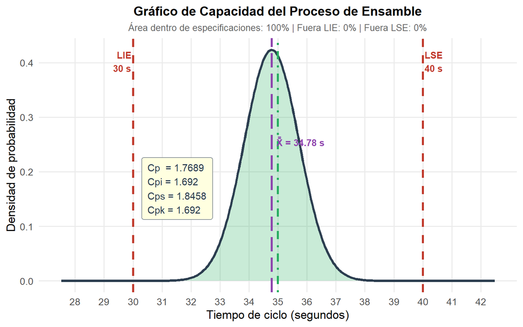

Figura 2. Análisis gráfico de capacidad del proceso

```r
# ============================================================
# Gráfico de capacidad con curva normal y especificaciones
# ============================================================

# Rango de valores para la curva normal del proceso
x_vals <- seq(LIE - 3, LSE + 3, length.out = 400)
y_vals <- dnorm(x_vals, mean = X_doble_barra, sd = sigma_est)

df_curva <- data.frame(x = x_vals, y = y_vals)

# Cálculo de áreas fuera de especificaciones (para anotación)
pct_fuera_inf <- round(pnorm(LIE, mean = X_doble_barra, sd = sigma_est) * 100, 4)
pct_fuera_sup <- round((1 - pnorm(LSE, mean = X_doble_barra, sd = sigma_est)) * 100, 4)
pct_dentro    <- round(100 - pct_fuera_inf - pct_fuera_sup, 4)

ggplot(df_curva, aes(x = x, y = y)) +
  # Área dentro de especificaciones (verde)
  geom_area(
    data = subset(df_curva, x >= LIE & x <= LSE),
    fill = "#27AE60", alpha = 0.25
  ) +
  # Área fuera de LIE (rojo izquierda)
  geom_area(
    data = subset(df_curva, x < LIE),
    fill = "#E74C3C", alpha = 0.45
  ) +
  # Área fuera de LSE (rojo derecha)
  geom_area(
    data = subset(df_curva, x > LSE),
    fill = "#E74C3C", alpha = 0.45
  ) +
  # Curva normal del proceso
  geom_line(color = "#2C3E50", linewidth = 1.3) +
  # Líneas de especificación
  geom_vline(xintercept = LIE, color = "#C0392B", linewidth = 1.2, linetype = "dashed") +
  geom_vline(xintercept = LSE, color = "#C0392B", linewidth = 1.2, linetype = "dashed") +
  # Nominal y media del proceso
  geom_vline(xintercept = N,               color = "#27AE60", linewidth = 1.1, linetype = "dotdash") +
  geom_vline(xintercept = X_doble_barra,   color = "#8E44AD", linewidth = 1.1, linetype = "longdash") +
  # Etiquetas
  annotate("text", x = LIE, y = max(y_vals) * 0.95,
           label = paste0("LIE\n", LIE, " s"), color = "#C0392B", hjust = 1.1,
           size = 3.5, fontface = "bold") +
  annotate("text", x = LSE, y = max(y_vals) * 0.95,
           label = paste0("LSE\n", LSE, " s"), color = "#C0392B", hjust = -0.1,
           size = 3.5, fontface = "bold") +
  annotate("text", x = X_doble_barra, y = max(y_vals) * 0.60,
           label = paste0("X̄̄ = ", round(X_doble_barra, 2), " s"),
           color = "#8E44AD", hjust = -0.1, size = 3.5, fontface = "bold") +
  # Anotación de índices de capacidad
  annotate("label",
           x = LIE + 0.3, y = max(y_vals) * 0.40,
           label = paste0(
             "Cp  = ", round(Cp,  4), "\n",
             "Cpi = ", round(Cpi, 4), "\n",
             "Cps = ", round(Cps, 4), "\n",
             "Cpk = ", round(Cpk, 4)
           ),
           hjust = 0, size = 3.8, color = "#2C3E50",
           fill = "lightyellow", label.padding = unit(0.5, "lines")) +
  scale_x_continuous(
    limits = c(LIE - 2.5, LSE + 2.5),
    breaks = seq(LIE - 2, LSE + 2, by = 1)
  ) +
  labs(
    title    = "Gráfico de Capacidad del Proceso de Ensamble",
    subtitle = paste0("Área dentro de especificaciones: ", pct_dentro, "% | ",
                      "Fuera LIE: ", pct_fuera_inf, "% | ",
                      "Fuera LSE: ", pct_fuera_sup, "%"),
    x        = "Tiempo de ciclo (segundos)",
    y        = "Densidad de probabilidad"
  ) +
  theme_minimal(base_size = 13) +
  theme(
    plot.title    = element_text(face = "bold", hjust = 0.5, size = 14),
    plot.subtitle = element_text(hjust = 0.5, color = "gray40", size = 10),
    panel.grid.minor = element_blank()
  )
```

### 1.2.4 Interpretación de los Índices de Capacidad

A partir de los resultados obtenidos se presenta el siguiente análisis:

**1. Índice de Capacidad Potencial ($C_p$ = 1.7689):** El $C_p$ mide exclusivamente la relación entre la amplitud de la tolerancia (LSE – LIE = 10 s) y la dispersión natural del proceso ($6\hat{\sigma}$ = 5.6532 s), sin tener en cuenta el centrado. Un valor de $C_p$ = **1.7689** indica que el proceso posee una capacidad potencial **satisfactoria (proceso de primera categoría, Cp ≥ 1.33)**. En términos prácticos, la dispersión natural del proceso es considerablemente menor que la ventana de tolerancia disponible.

**2. Índice de Capacidad Inferior ($C_{pi}$ = 1.692):** Este índice cuantifica el desempeño del proceso con relación al Límite de Especificación Inferior. El valor obtenido ($C_{pi}$ = 1.692) sugiere que el proceso mantiene una distancia **holgada y adecuada** entre la media del proceso y el LIE.

**4. Índice de Capacidad Real ($C_{pk}$ = 1.692):** El $C_{pk}$ representa el índice más conservador y realista, ya que incorpora simultáneamente el efecto de la variabilidad y del centrado del proceso. Su valor es $C_{pk}$ = **1.692**. Dado que $C_{pk}$ < $C_p$ (1.692 < 1.7689), se confirma que el proceso **no está perfectamente centrado** respecto al valor nominal de 35 s. Sin embargo, el índice supera el umbral de referencia de 1.00, lo que indica que el proceso es capaz de cumplir con las especificaciones establecidas.

**Categoría del Proceso:** Con base en los criterios de la literatura especializada en Seis Sigma y CEP, el proceso de ensamble de cubos Lego se clasifica como **un proceso de clase mundial (Cp, Cpk ≥ 1.67)**.

# 2 Estudio de Estabilidad Estadística

El estudio de estabilidad estadística busca determinar si el proceso de ensamble opera bajo la influencia exclusiva de causas comunes de variación, es decir, si se encuentra en estado de **control estadístico**. Para ello se emplean las cartas de control como herramienta principal de análisis.

## 2.1 Elaboración de las Cartas de Control del Proceso

### 2.1.1 Elección de los Tipos de Cartas de Control Adecuadas

La selección del tipo de carta de control apropiado depende de la naturaleza de la característica de calidad y del esquema de muestreo empleado. En el presente estudio, los criterios de decisión son los siguientes:

1. **Naturaleza de la variable:** El tiempo de ciclo de ensamble es una **variable continua** de escala de razón, expresada en segundos. Esto determina que se utilicen cartas de control por variables, en contraposición a las cartas por atributos (p, np, c, u), que son aplicables únicamente a datos discretos o de conteo.
2. **Tamaño del subgrupo ($n = 4$):** Dado que el tamaño del subgrupo es pequeño y constante ($n = 4$, con $2 \leq n \leq 9$), el **Rango** ($R$) es el estadístico adecuado para estimar la variabilidad intragrupal. Para subgrupos de mayor tamaño ($n \geq 10$), se preferiría la carta de Desviación Estándar ($\bar{X}$–$S$).
3. **Información sobre la localización y la dispersión:** Las cartas de control por variables se emplean en pares. La carta $\bar{X}$ (Media) monitorea el centrado del proceso, detectando desplazamientos en la tendencia central; mientras que la carta $R$ (Rango) monitorea la dispersión, detectando cambios en la variabilidad del proceso.

Por lo anterior, se justifica plenamente el uso de las cartas **$\bar{X}$–$R$** (Media y Rango) como el par de cartas de control adecuado para este estudio.

### 2.1.2 Interpretación de las Cartas (Límites, Puntos Fuera de Límites y Patrones Especiales)

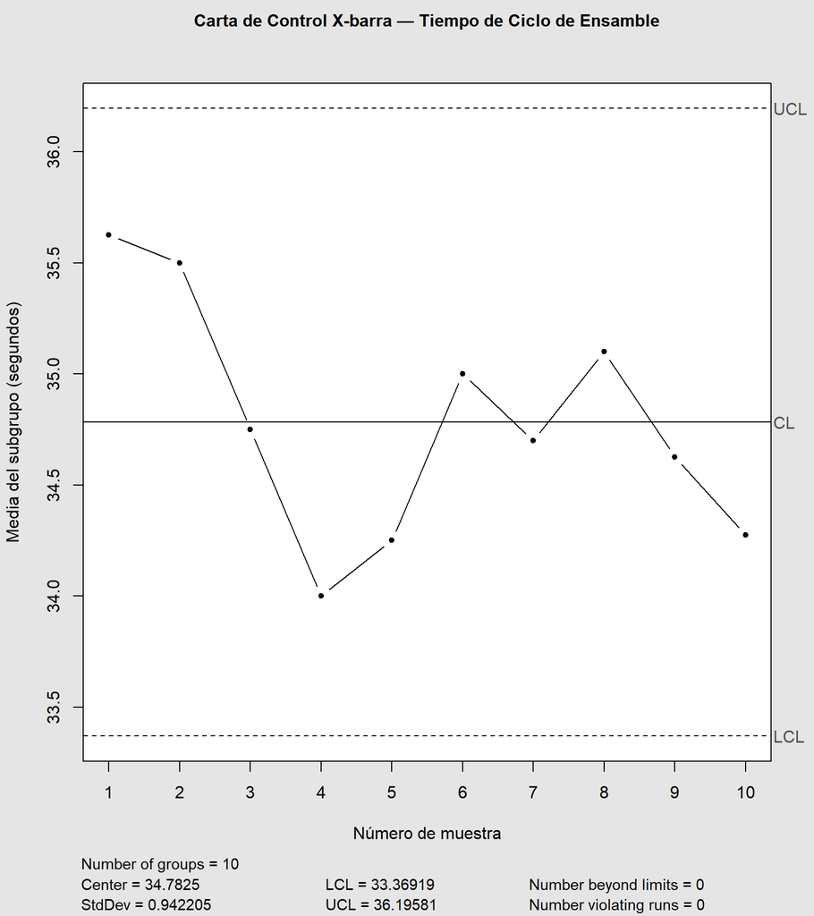

```r
# ============================================================
# Construcción de las cartas de control X-barra y R
# con la librería qcc
# ============================================================

# Constantes de control para n = 4
# A2 = 0.729, D3 = 0 (no existe LCI para R con n<7), D4 = 2.282
A2 <- 0.729
D3 <- 0        # Factor D3 para n=4 (LCI de R = 0)
D4 <- 2.282    # Factor D4 para n=4

# --- Cálculo manual de límites ---

# Carta X-barra
LCS_Xbar <- X_doble_barra + A2 * R_bar
LC_Xbar  <- X_doble_barra
LCI_Xbar <- X_doble_barra - A2 * R_bar

# Carta R
LCS_R <- D4 * R_bar
LC_R  <- R_bar
LCI_R <- D3 * R_bar    # = 0 para n=4

# Medias y Rangos de cada subgrupo
medias_subgrupos <- apply(obs_matrix, 1, mean)
rangos_subgrupos <- apply(obs_matrix, 1, function(x) max(x) - min(x))

# ---- CARTA X-BARRA (con qcc) ----
qcc_xbar <- qcc(
  data      = obs_matrix,
  type      = "xbar",
  title     = "Carta de Control X-barra — Tiempo de Ciclo de Ensamble",
  xlab      = "Número de muestra",
  ylab      = "Media del subgrupo (segundos)",
  plot      = TRUE,
  add.stats = TRUE
)
```

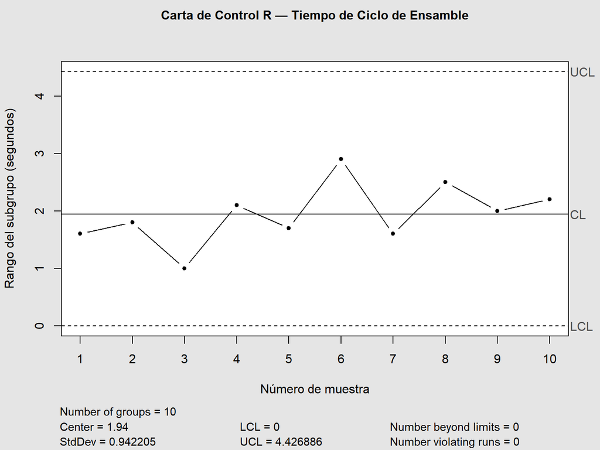

Figura 4. Carta de control R para el proceso de ensamble de cubos Lego

```r
# ---- CARTA R (con qcc) ----
qcc_R <- qcc(
  data      = obs_matrix,
  type      = "R",
  title     = "Carta de Control R — Tiempo de Ciclo de Ensamble",
  xlab      = "Número de muestra",
  ylab      = "Rango del subgrupo (segundos)",
  plot      = TRUE,
  add.stats = TRUE
)
```

```r
# ============================================================
# Tabla resumen de límites de control calculados
# ============================================================
limites_df <- data.frame(
  Carta  = c("$\\bar{X}$", "$\\bar{X}$", "$\\bar{X}$", "$R$", "$R$", "$R$"),
  Límite = c("LCS", "Línea Central (LC)", "LCI",
             "LCS", "Línea Central (LC)", "LCI"),
  Fórmula = c(
    "$\\bar{\\bar{X}} + A_2 \\bar{R}$",
    "$\\bar{\\bar{X}}$",
    "$\\bar{\\bar{X}} - A_2 \\bar{R}$",
    "$D_4 \\bar{R}$",
    "$\\bar{R}$",
    "$D_3 \\bar{R}$"
  ),
  Valor = round(c(LCS_Xbar, LC_Xbar, LCI_Xbar, LCS_R, LC_R, LCI_R), 4)
)

limites_df %>%
  kable(
    caption = "Tabla 4. Límites de control calculados para las cartas X-barra y R",
    align   = c("c", "l", "c", "c"),
    escape  = FALSE
  ) %>%
  kable_styling(
    bootstrap_options = c("striped", "hover", "bordered"),
    full_width        = FALSE,
    position          = "center"
  ) %>%
  row_spec(0, bold = TRUE, background = "#2980B9", color = "white") %>%
  pack_rows("Carta X-barra", 1, 3, bold = TRUE, background = "#D6EAF8") %>%
  pack_rows("Carta R",       4, 6, bold = TRUE, background = "#D5F5E3")
```

Tabla 4. Límites de control calculados para las cartas X-barra y R

| Carta | Límite | Fórmula | Valor |
| --- | --- | --- | --- |
| **Carta X-barra** |  |  |  |
| $\bar{X}$ | LCS | $\bar{\bar{X}} + A_2 \bar{R}$ | 36.1968 |
| $\bar{X}$ | Línea Central (LC) | $\bar{\bar{X}}$ | 34.7825 |
| $\bar{X}$ | LCI | $\bar{\bar{X}} - A_2 \bar{R}$ | 33.3682 |
| **Carta R** |  |  |  |
| $R$ | LCS | $D_4 \bar{R}$ | 4.4271 |
| $R$ | Línea Central (LC) | $\bar{R}$ | 1.9400 |
| $R$ | LCI | $D_3 \bar{R}$ | 0.0000 |

```r
# ============================================================
# Identificación de puntos fuera de los límites de control
# ============================================================

# --- Carta X-barra ---
puntos_fuera_xbar <- which(
  medias_subgrupos > LCS_Xbar | medias_subgrupos < LCI_Xbar
)

# --- Carta R ---
puntos_fuera_R <- which(
  rangos_subgrupos > LCS_R | rangos_subgrupos < LCI_R
)

cat("=== ANÁLISIS DE PUNTOS FUERA DE CONTROL ===\n\n")
```

```
## === ANÁLISIS DE PUNTOS FUERA DE CONTROL ===
```

```r
# X-barra
cat(sprintf("Carta X-barra:\n"))
```

```
## Carta X-barra:
```

```r
cat(sprintf("  LCI = %.4f | LC = %.4f | LCS = %.4f\n",
            LCI_Xbar, LC_Xbar, LCS_Xbar))
```

```
##   LCI = 33.3682 | LC = 34.7825 | LCS = 36.1968
```

```r
cat(sprintf("  Medias por subgrupo: %s\n",
            paste(round(medias_subgrupos, 4), collapse = ", ")))
```

```
##   Medias por subgrupo: 35.625, 35.5, 34.75, 34, 34.25, 35, 34.7, 35.1, 34.625, 34.275
```

```r
if (length(puntos_fuera_xbar) == 0) {
  cat("  >> Ningún punto fuera de los límites de control.\n\n")
} else {
  cat(sprintf("  >> Puntos fuera de control en muestra(s): %s\n\n",
              paste(puntos_fuera_xbar, collapse = ", ")))
}
```

```
##   >> Ningún punto fuera de los límites de control.
```

```r
# Carta R
cat(sprintf("Carta R:\n"))
```

```
## Carta R:
```

```r
cat(sprintf("  LCI = %.4f | LC = %.4f | LCS = %.4f\n",
            LCI_R, LC_R, LCS_R))
```

```
##   LCI = 0.0000 | LC = 1.9400 | LCS = 4.4271
```

```r
cat(sprintf("  Rangos por subgrupo: %s\n",
            paste(round(rangos_subgrupos, 4), collapse = ", ")))
```

```
##   Rangos por subgrupo: 1.6, 1.8, 1, 2.1, 1.7, 2.9, 1.6, 2.5, 2, 2.2
```

```r
if (length(puntos_fuera_R) == 0) {
  cat("  >> Ningún punto fuera de los límites de control.\n")
} else {
  cat(sprintf("  >> Puntos fuera de control en muestra(s): %s\n",
              paste(puntos_fuera_R, collapse = ", ")))
}
```

```
##   >> Ningún punto fuera de los límites de control.
```

**Análisis de la Carta $\bar{X}$:** La carta de medias muestra la línea central en $\bar{\bar{X}}$ = 34.7825 s, con un Límite de Control Superior (LCS) de 36.1968 s y un Límite de Control Inferior (LCI) de 33.3682 s. Ningún punto de las 10 muestras cae fuera de los límites de control, lo que indica que el proceso opera bajo causas comunes de variación en lo que respecta a la tendencia central.

**Análisis de la Carta $R$:** La carta de rangos presenta la línea central en $\bar{R}$ = 1.94 s, un LCS de 4.4271 s y un LCI de 0 s (igual a cero, lo cual es esperado para $n = 4$ con $D_3 = 0$). Ningún punto excede los límites de control, lo que evidencia que la dispersión intragrupal del proceso permanece estable a lo largo del tiempo de estudio.

**Patrones especiales:** Adicionalmente al criterio de puntos fuera de control, se examina visualmente la presencia de patrones no aleatorios (rachas, tendencias, ciclicidad, estratificación). Dado que el número de observaciones es reducido ($k = 10$ subgrupos), el análisis de patrones se limita a la inspección visual, sin aplicar la totalidad de las reglas de Western Electric o Nelson, cuya potencia estadística es mayor en series temporales más extensas.

### 2.1.3 Cálculo del Índice de Inestabilidad ($S_t$)

El Índice de Inestabilidad ($S_t$) es un indicador cuantitativo del grado de descontrol estadístico de un proceso, expresado como el porcentaje de puntos que caen fuera de los límites de control respecto al total de puntos graficados.

```r
# ============================================================
# Cálculo del Índice de Inestabilidad (St)
# Fórmula: St = (Puntos fuera de control / Total de puntos) × 100
# ============================================================

# Total de puntos graficados (k muestras en cada carta)
total_puntos_xbar <- k
total_puntos_R    <- k

# Puntos fuera de control
n_fuera_xbar <- length(puntos_fuera_xbar)
n_fuera_R    <- length(puntos_fuera_R)

# Índice de inestabilidad por carta
St_xbar <- (n_fuera_xbar / total_puntos_xbar) * 100
St_R    <- (n_fuera_R    / total_puntos_R)    * 100

# Índice de inestabilidad global (considerando ambas cartas en conjunto)
total_puntos_global <- total_puntos_xbar + total_puntos_R
n_fuera_global      <- n_fuera_xbar + n_fuera_R
St_global           <- (n_fuera_global / total_puntos_global) * 100

# Tabla de resultados
st_df <- data.frame(
  Carta                     = c("X-barra", "R", "Global (X-barra + R)"),
  `Total de puntos`         = c(total_puntos_xbar, total_puntos_R, total_puntos_global),
  `Puntos fuera de control` = c(n_fuera_xbar, n_fuera_R, n_fuera_global),
  `St (%)`                  = round(c(St_xbar, St_R, St_global), 2),
  check.names               = FALSE
)

st_df %>%
  kable(
    caption = "Tabla 5. Índice de Inestabilidad (St) por carta de control",
    align   = c("l", "c", "c", "c")
  ) %>%
  kable_styling(
    bootstrap_options = c("striped", "hover", "bordered"),
    full_width        = FALSE,
    position          = "center"
  ) %>%
  row_spec(0, bold = TRUE, background = "#2980B9", color = "white") %>%
  row_spec(3, bold = TRUE, background = "#EBF5FB")
```

Tabla 5. Índice de Inestabilidad (St) por carta de control

| Carta | Total de puntos | Puntos fuera de control | St (%) |
| --- | --- | --- | --- |
| X-barra | 10 | 0 | 0 |
| R | 10 | 0 | 0 |
| Global (X-barra + R) | 20 | 0 | 0 |

**Criterios de clasificación del $S_t$:**

| Rango de $S_t$ | Clasificación del proceso |
| --- | --- |
| $S_t = 0\%$ | Proceso en control estadístico perfecto |
| $0\% < S_t \leq 5\%$ | Proceso razonablemente estable |
| $5\% < S_t \leq 25\%$ | Proceso con inestabilidad moderada |
| $S_t > 25\%$ | Proceso estadísticamente inestable |

**Conclusión sobre la Estabilidad del Sistema:**

El Índice de Inestabilidad calculado para la carta $\bar{X}$ es $S_{t(\bar{X})}$ = **0%**, para la carta $R$ es $S_{t(R)}$ = **0%**, y el índice global que consolida ambas cartas resulta en $S_t$ = **0%**.

Con un índice de inestabilidad global del **0%**, se concluye que el proceso de ensamble de cubos Lego se encuentra en un estado de **control estadístico pleno**. La ausencia de puntos fuera de los límites de control en ambas cartas indica que toda la variación observada es atribuible exclusivamente a causas comunes —inherentes al sistema—, sin evidencia de causas asignables de variación que perturben el proceso. En consecuencia, el proceso es estadísticamente estable y predecible dentro de los límites de control establecidos.

## 2.2 Resumen Ejecutivo de los Estudios

```r
# ============================================================
# Tabla de resumen ejecutivo de los hallazgos principales
# ============================================================
resumen_df <- data.frame(
  Indicador = c(
    "Media global del proceso ($\\bar{\\bar{X}}$)",
    "Sigma estimada ($\\hat{\\sigma}$)",
    "Rango medio ($\\bar{R}$)",
    "Índice $C_p$",
    "Índice $C_{pi}$",
    "Índice $C_{ps}$",
    "Índice $C_{pk}$",
    "LCS – Carta $\\bar{X}$",
    "LCI – Carta $\\bar{X}$",
    "LCS – Carta $R$",
    "Puntos fuera de control ($\\bar{X}$)",
    "Puntos fuera de control ($R$)",
    "Índice de Inestabilidad $S_t$ (global)"
  ),
  Valor = c(
    paste0(round(X_doble_barra, 4), " s"),
    paste0(round(sigma_est, 4),     " s"),
    paste0(round(R_bar, 4),         " s"),
    round(Cp,  4),
    round(Cpi, 4),
    round(Cps, 4),
    round(Cpk, 4),
    paste0(round(LCS_Xbar, 4), " s"),
    paste0(round(LCI_Xbar, 4), " s"),
    paste0(round(LCS_R, 4),    " s"),
    n_fuera_xbar,
    n_fuera_R,
    paste0(St_global, "%")
  ),
  Evaluación = c(
    ifelse(abs(X_doble_barra - N) <= 0.5, "✓ Próxima al nominal", "⚠ Desviada del nominal"),
    "— Parámetro estimado",
    "— Parámetro estimado",
    ifelse(Cp  >= 1.33, "✓ Proceso capaz (1ª categoría)",
           ifelse(Cp  >= 1.00, "⚠ Proceso adecuado (2ª categoría)", "✗ Proceso no capaz")),
    ifelse(Cpi >= 1.33, "✓ Adecuado vs. LIE", ifelse(Cpi >= 1.00, "⚠ Adecuado vs. LIE", "✗ Inadecuado vs. LIE")),
    ifelse(Cps >= 1.33, "✓ Adecuado vs. LSE", ifelse(Cps >= 1.00, "⚠ Adecuado vs. LSE", "✗ Inadecuado vs. LSE")),
    ifelse(Cpk >= 1.33, "✓ Proceso capaz y bien centrado",
           ifelse(Cpk >= 1.00, "⚠ Capaz, centrado mejorable", "✗ Proceso no capaz")),
    "— Límite de referencia",
    "— Límite de referencia",
    "— Límite de referencia",
    ifelse(n_fuera_xbar == 0, "✓ Ninguno", paste0("⚠ ", n_fuera_xbar, " punto(s)")),
    ifelse(n_fuera_R    == 0, "✓ Ninguno", paste0("⚠ ", n_fuera_R,    " punto(s)")),
    ifelse(St_global == 0,     "✓ Proceso estable (St = 0%)",
           ifelse(St_global <= 5, "⚠ Razonablemente estable",
                  "✗ Proceso inestable"))
  )
)

resumen_df %>%
  kable(
    caption = "Tabla 6. Resumen ejecutivo de los estudios de capacidad y estabilidad",
    align   = c("l", "c", "l"),
    escape  = FALSE
  ) %>%
  kable_styling(
    bootstrap_options = c("striped", "hover", "bordered"),
    full_width        = TRUE,
    position          = "center"
  ) %>%
  row_spec(0, bold = TRUE, background = "#2C3E50", color = "white") %>%
  pack_rows("Parámetros Descriptivos del Proceso", 1, 3,
            bold = TRUE, background = "#D6EAF8") %>%
  pack_rows("Índices de Capacidad",                4, 7,
            bold = TRUE, background = "#D5F5E3") %>%
  pack_rows("Cartas de Control",                   8, 13,
            bold = TRUE, background = "#FDEBD0")
```

Tabla 6. Resumen ejecutivo de los estudios de capacidad y estabilidad

| Indicador | Valor | Evaluación |
| --- | --- | --- |
| **Parámetros Descriptivos del Proceso** |  |  |
| Media global del proceso ($\bar{\bar{X}}$) | 34.7825 s | ✓ Próxima al nominal |
| Sigma estimada ($\hat{\sigma}$) | 0.9422 s | — Parámetro estimado |
| Rango medio ($\bar{R}$) | 1.94 s | — Parámetro estimado |
| **Índices de Capacidad** |  |  |
| Índice $C_p$ | 1.7689 | ✓ Proceso capaz (1ª categoría) |
| Índice $C_{pi}$ | 1.692 | ✓ Adecuado vs. LIE |
| Índice $C_{ps}$ | 1.8458 | ✓ Adecuado vs. LSE |
| Índice $C_{pk}$ | 1.692 | ✓ Proceso capaz y bien centrado |
| **Cartas de Control** |  |  |
| LCS – Carta $\bar{X}$ | 36.1968 s | — Límite de referencia |
| LCI – Carta $\bar{X}$ | 33.3682 s | — Límite de referencia |
| LCS – Carta $R$ | 4.4271 s | — Límite de referencia |
| Puntos fuera de control ($\bar{X}$) | 0 | ✓ Ninguno |
| Puntos fuera de control ($R$) | 0 | ✓ Ninguno |
| Índice de Inestabilidad $S_t$ (global) | 0% | ✓ Proceso estable (St = 0%) |

*Documento generado en R Markdown. Fecha de compilación: 05 de October de 2026, 20:00:54.*